# Australian Atlas

Nicholas Tierney

2019-08-02

## Making a report

Let’s read in data with `read_csv`:

```r
library(readr)
platypus <- read_csv(here::here("data/platypus.csv"))
# platypus <- read_csv(here::here("exercises/1b/data/platypus.csv"))
```

This code can be read as: “read in this .csv file from the data folder”.

(We’ll talk more about what `here::here` means in an upcoming lecture.)

Task: - Add a section header called “About the data” to your document. Write a paragraph about the “Atlas of Living Australia” (use your internet search skills!). - You could even try adding a picture of a platypus into your report. You can do this using markdown syntax or `include_graphics()` - try looking online for the rstudio markdown cheatsheet, or typing `?include_graphics()` into the console.

## Adding plots

Let’s make some plots.

Two of the variables in the data set are the latitude and longitude indicating where the animal was spotted. This is going to be the first plot, made using the `ggplot2` package from `tidyverse` suite.

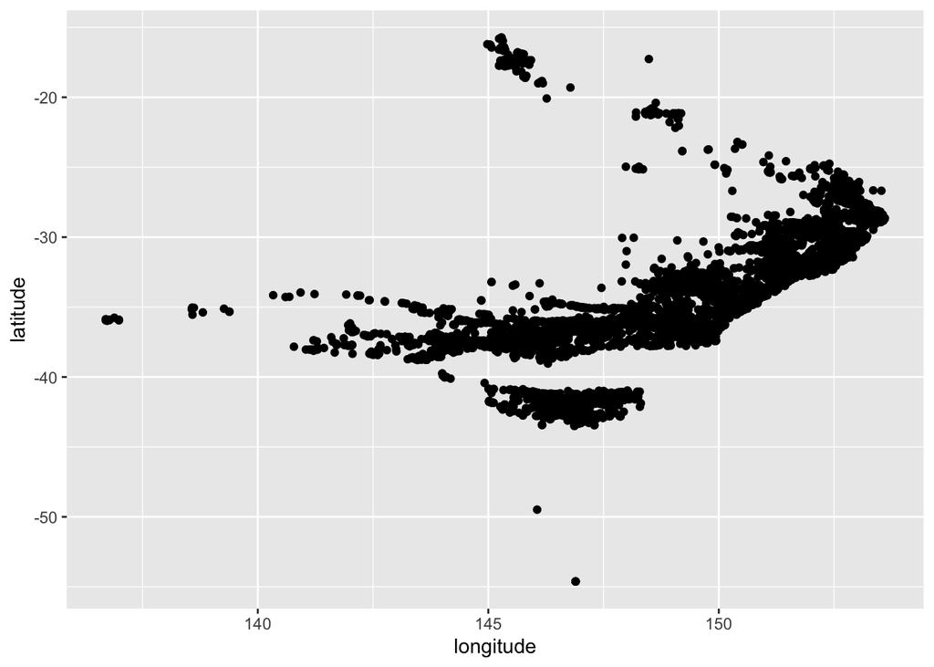

## look at the data

Use `View(platypus)` to open a “spreadsheet” view of the data.

What do you see?

What was the year with the most platypus?

How do you think you would work that out?

What steps would you need to take?

We will cover how to answer these kinds of questions and more in class!

While we can look at the data in a spreadsheet, we can’t answer those questions.

We need to do some data manipulation and summarising using tools from R!

## subsetting the data

Let’s subset the data to only look at platypus sightings from Victoria

```r
platypus_vic <- platypus %>%
  filter(state == "Victoria")
```

## Appendix

Below contains the code used to download the data

```r
# load the ALA4R package, which contains the platypus data
library(ALA4R)
# Take a look at what the package does using the code `help(package="ALA4R")`

# Look up the scientific name for platypus using:
specieslist("platypus")

# This returns a lot of different organisms with "platypus" in the name, but you should be able to find one line with the relevant information, that its scientific name is "Ornithorhynchus anatinus".

platypus <- occurrences("Ornithorhynchus anatinus", download_reason_id=10)

# 518426.7 is NOWHERE near Australia. Let's filter it out

# subset the data using dplyr filter and select commands
platypus <- platypus$data %>%
  filter(longitude < 518426) %>%
  select(id,
         commonName,
         scientificName,
         state,
         latitude,
         longitude,
         eventDate,
         sex) %>%
  as_tibble()

# write_csv(platypus, here::here("exercises/1b/data/platypus.csv"))
write_csv(platypus, here::here("data/platypus.csv"))

# You can learn more about `read_csv` and `write_csv` by typing `?write_csv`.
```